# STAT5002 Lab2 Worksheet

Introduction to Statistics

University of Sydney STAT5002

# 1 Import data and IDA

- Save the data-file `math1005_cleaned.csv` in your data folder within your STAT5002 folder.
- **Import** the data into a variable called `math1005`:

```r
math1005 = read.csv("data/math1005_cleaned.csv")
```

This data was collected from an **optional survey** for MATH1005 students at the start of 2022 Semester 2. There are a total of **928 students** enrolled in this course. We will also use this data set next week in lectures.

- How many survey **responses** are there? How many **variables** are there?

```r
### write code here
```

- What are the **columns** of your data and what are their **type**? Are they classified correctly?
  - *Hint: Use the function `str`. Other useful functions are `names` and`head`*.

```r
### write code here
```

# 2 Quantitative Data

## 2.1 Height

- Create a **graphical summary** for the **height** distribution of the cohort. Comment on the distribution, are there any **outliers**? Are there any issues with the data?

```r
### write code here
```

- Calculate some **numerical summaries** for the **heights**. Briefly summarise your findings. Here you may need to remove `NA`s in the variable before proceed.

**Hint:** check `?na.omit` for removing `NA`s.

```r
### write code here
```

## 2.2 Write a function in R to compute the population standard deviation

In the lectures, we learned how to write a function in R. Here is your turn, we want to write a function to compute the **population standard deviation** of a data set. Let’s name the function `sdpop`.

- Complete the function in the following.

```r
# complete the following function
sdpop <- function(X){
  ### write your code here

}
```

- Calculate the population SD of height and check if it is correct.

```r
### Apply your function sdpop here to height and check its correctness
```

## 2.3 Age

- Create a **graphical summary** for the **age** distribution of the cohort. Comment on the distribution, are there any **outliers**? Are there any issues with the data?

```r
### write code here
```

- Calculate some **numerical summaries** for the **ages**. Briefly summarise your findings.

```r
### write code here
```

## 2.4 Shoe Size

- Create a **graphical summary** for the **shoe size** distribution of the cohort. Comment on the distribution, are there any **outliers**? Are there any issues with the data? **Hint:** Some might response using a different shoe size convention, perhaps using EU instead of US.

```r
### write code here
```

- Perform any appropriate **data cleaning**. You may also need to remove `NA`s here.

```r
### write code here
```

- Calculate some **numerical summaries** for the **shoe sizes**. Briefly summarise your findings.

```r
### write code here
```

# 3 Qualitative Data

## 3.1 International

- Create a **graphical summary** for the distribution of **domestic and international students** in the cohort.
  - *Hint: what type of graphical summary would be the most appropriate? You can refer to code in previous lectures and labs*.

```r
### write code here
```

- What is the **proportion** of **international students**? Briefly summarise your findings.
  - *Hint: `math1005$International == "International"` creates a list of `TRUE` and `FALSE` of whether each student is international or not. R can interpret `TRUE` as 1 and `FALSE` as 0.*

```r
### write code here
```

## 3.2 Gender

- Create a **graphical summary** for the **gender** distribution of the cohort.

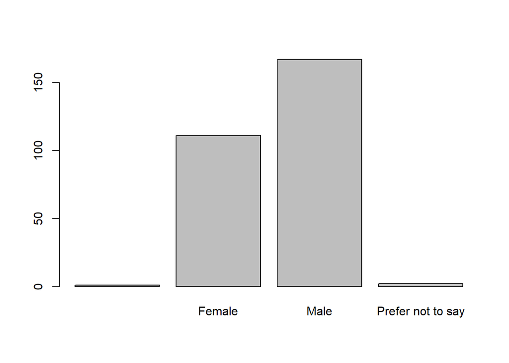

```r
### write code here
barplot(table(math1005$Gender))
```

- What is the **proportion** of **females**? Briefly summarise your findings

```r
### write code here
```

## 3.3 Country

This task contains some additional visualisation techniques not covered in lectures. These are not mandatory for learning other topics of this unit but can be useful in real life.

- Create a **barplot** for the **Country** that the students in the cohort were born in. Is it meaningful? Are there any issues with the data? How could this be improved?

```r
### write code here
```

- Make a barplot of the **top 10 countries** among the cohort. Briefly summarise your findings.
  - *Hint: the `sort` function might be useful!*

```r
### write code here
```

You will need to first **install the** `wordcloud` **and** `tm` **packages**. To do this, you can run the first line without the `#`. Once installed, they will remain on your computer and you do not need to run this line ever again. But in each document you want to make a word cloud, you will need to include `library(wordcloud)` to **load the package**.

```r
#install.packages(c("wordcloud", "tm"))
#library(wordcloud)
#wordcloud(math1005$Country, min.freq = 1)
```